# Vectors

# Cartesian Coordinate System

## Introduction

The Cartesian coordinate system is a two-dimensional coordinate system that allows us to represent points in a plane using two perpendicular lines called the x-axis and y-axis. The x-axis is the horizontal line, and the y-axis is the vertical line. The point where the two axes intersect is called the origin, denoted by O.

## Cartesian spaces

### Coordinate Systems

```
Normalized v1: [0.62469505 0.78086881]
Normalized v2: [ 0.9701425  -0.24253563]
```

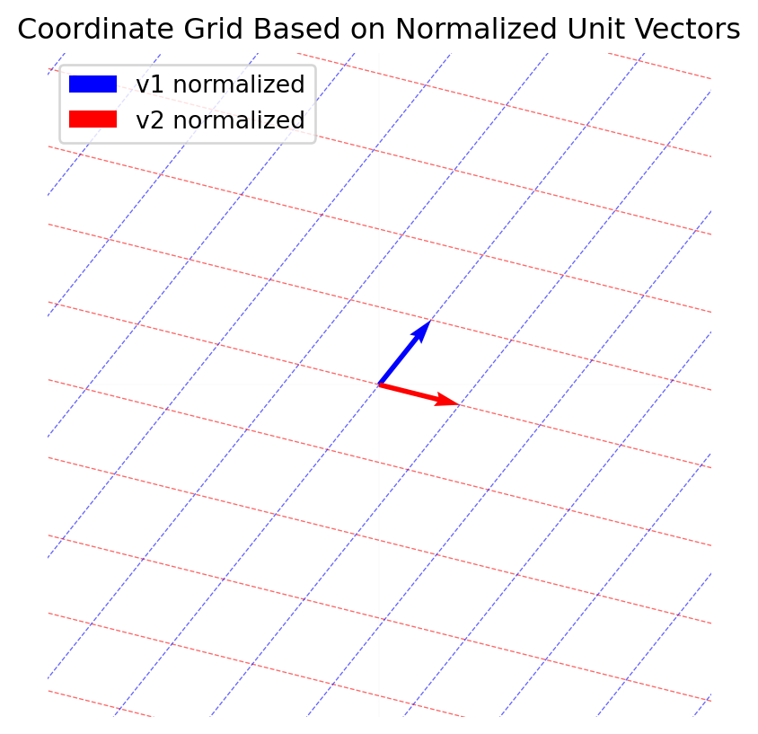

```python
v1 = np.array([4, 5])  # some arbitrary vector
v2 = np.array([4, -1]) # another arbitrary vector

plot_coordinate_grid(v1, v2, grid_size=4)
```

[figure not shown]

```
Vector components in basis 1: [3. 2.]
Vector components in basis 2: [2.82842712 5.        ]
```

```python
# Example: Using non-standard vectors and a vector in space
v1_basis1 = np.array([1,0])  # first versor of basis 1
v2_basis1 = np.array([0,1]) # second versor of basis 1
v1_basis2 = np.array([-1, 1])  # first versor of basis 2
v2_basis2 = np.array([1, 0])  # second versor of basis 2

vector = np.array([3, 2])  # Vector in cartesian coordinates

plot_side_by_side_systems(v1_basis1, v2_basis1, v1_basis2, v2_basis2, vector)
```

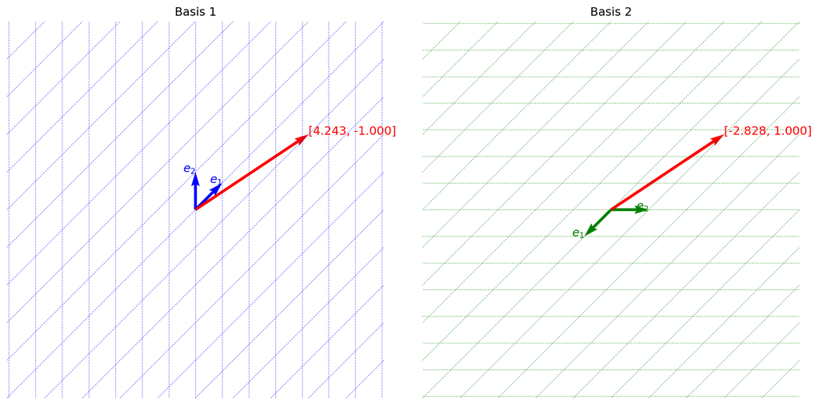

```
Vector components in basis 1: [ 4.24264069 -1.        ]
Vector components in basis 2: [-2.82842712  1.        ]
```

```python
# Example: Using non-standard vectors and a vector in space
v1_basis1 = np.array([1,1])  # first versor of basis 1
v2_basis1 = np.array([0,1]) # second versor of basis 1
v1_basis2 = np.array([-1, -1])  # first versor of basis 2
v2_basis2 = np.array([1, 0])  # second versor of basis 2

vector = np.array([3, 2])  # Vector in the cartesian coordinates

plot_side_by_side_systems(v1_basis1, v2_basis1, v1_basis2, v2_basis2, vector)
```

### Definition by Remik - old

**Vectors** are quantities that have both magnitude and direction in space. They are used to describe various physical quantities such as velocity, force, or electric field intensity. Unlike scalars, which have only magnitude (e.g., mass, temperature), vectors require a direction to be specified.

A vector is represented with an arrow above the symbol $\vec{a}$ or in bold type $\mathbf{a}$. - The magnitude of a vector can be written as $\vec{a}|$ or $a$. - A vector of length 1 is called a unit vector and is denoted by $\hat{\mathbf{a}} = \frac{\vec{a}}{|\vec{a}|}$.

**Example:**

The vector $\mathbf{a}= [3, 4]$ has a magnitude $a = 5$, and the corresponding unit vector (unit vector along the direction of vector $\mathbf{a}$) is expressed as $\hat{\mathbf{a}} = \left[\frac{3}{5}, \frac{4}{5}\right]$.

### Coordinate Systems in the Plane and Space

**Cartesian Coordinate System** is the basic coordinate system in which points in space are specified by their distances from fixed axes: $x$, $y$ (for 2D) and $z$ (for 3D).

- In 2D, each point can be written as $(x, y)$.
- In 3D, points are of the form $(x, y, z)$.

**Polar Coordinate System** is used in 2D and defines a point by its distance from the origin (r) and the angle (θ) relative to the reference axis.

**Spherical Coordinate System** is used in 3D and defines a point by its distance from the origin (r), azimuth angle (θ), and elevation angle (φ).

Vectors can be represented using components in the Cartesian coordinate system, where each component corresponds to the distance of the point from the respective coordinate axis.

- For a vector in two-dimensional space: $\mathbf{a} = [a_x, a_y] = a_x\hat{\mathbf{i}} + a_y\hat{\mathbf{j}}$
- For a vector in three-dimensional space: $\mathbf{a} = [a_x, a_y, a_z] = a_x\hat{\mathbf{i}} + a_y\hat{\mathbf{j}} + a_z\hat{\mathbf{k}}$

### Basis

**Basis** of vectors is a set of vectors that spans a vector space. In Cartesian space, the standard basis vectors are $\hat{\mathbf{i}}, \hat{\mathbf{j}}, \hat{\mathbf{k}}$.

For 2D:

$$\hat{\mathbf{i}} = [1, 0], \quad \hat{\mathbf{j}} = [0, 1]$$

For 3D:

$$\hat{\mathbf{i}} = [1, 0, 0], \quad \hat{\mathbf{j}} = [0, 1, 0], \quad \hat{\mathbf{k}} = [0, 0, 1]$$

These basis vectors are unit vectors and are perpendicular to each other.

### Finding the Coordinates of a Vector in a New Basis

To find the coordinates of vector $\mathbf{v}$ in a new basis $\{\mathbf{b_1}, \mathbf{b_2}, \mathbf{b_3}\}$, express $\mathbf{v}$ as a linear combination of the basis vectors.

$$\mathbf{v} = c_1 \mathbf{b_1} + c_2 \mathbf{b_2} + c_3 \mathbf{b_3}$$

The coefficients $c_1, c_2, c_3$ are the coordinates of vector $\mathbf{v}$ in the new basis.

### Vector Addition

Vector addition involves adding the corresponding components of vectors of the same length.

For two vectors $\mathbf{a}$ and $\mathbf{b}$ in the space $\mathbb{R}^n$, where:

$$\mathbf{a} = [a_1, a_2, \dots, a_n], \quad \mathbf{b} = [b_1, b_2, \dots, b_n]$$

Vector addition is defined as follows:

$$\mathbf{a} + \mathbf{b} = [a_1 + b_1, a_2 + b_2, \dots, a_n + b_n]$$

### Scalar Multiplication of a Vector

Scalar multiplication of a vector involves multiplying each component of the vector by the same number.

For a vector $\mathbf{a}$ and a scalar $k$:

$$k \mathbf{a} = [k a_1, k a_2, \dots, k a_n]$$

### Vectors in the Plane and Space

**Vectors in 2D:**

If $\mathbf{a} = [a_x, a_y]$, then the magnitude is given by the formula $|\mathbf{a}| = a = \sqrt{a_x^2 + a_y^2}$.

**Vectors in 3D:**

If $\mathbf{a} = [a_x, a_y, a_z]$, then the magnitude of the vector is $|\mathbf{a}| = a = \sqrt{a_x^2 + a_y^2 + a_z^2}$.

### Plotting a Vector

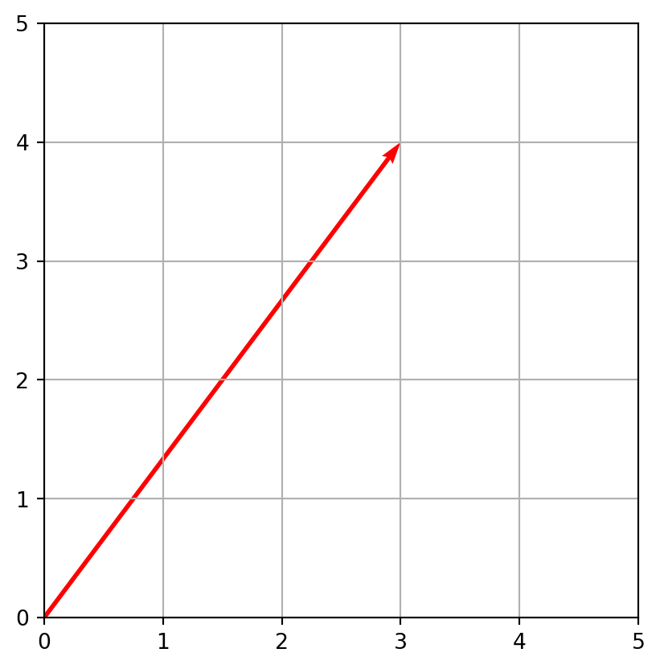

```python
import matplotlib.pyplot as plt # import the matplotlib.pyplot module

plt.figure() # create a new figure
plt.quiver(0, 0, 3, 4, angles='xy', scale_units='xy', scale=1, color='r') # quick way to plot a vector quiver(x_start, y_start, x_end, y_end)
plt.xlim(0, 5) # set x-axis range
plt.ylim(0, 5) # set y-axis range
plt.grid(True) # enable grid
plt.gca().set_aspect('equal') # set equal scaling on x and y axes
plt.show()
```

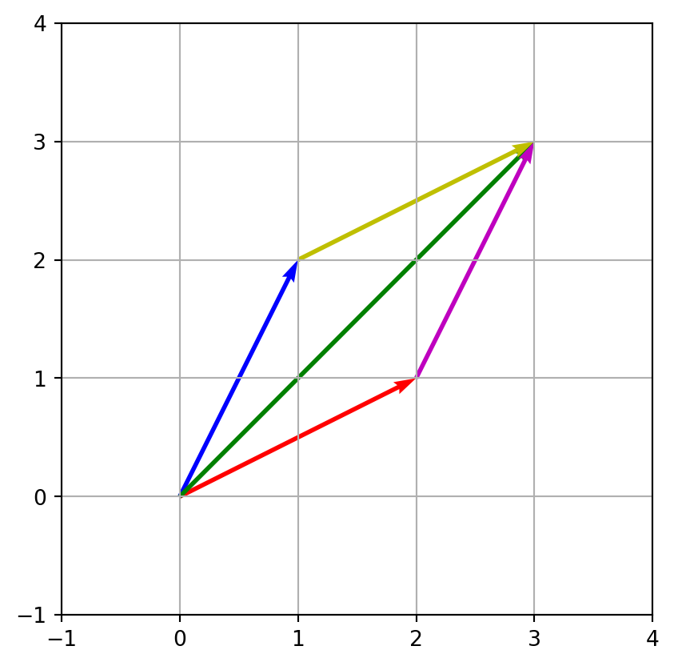

```python
import matplotlib.pyplot as plt # import the matplotlib.pyplot module #example of vector addition in two-dimensional space

plt.figure() # create a new figure
plt.quiver(0, 0, 2, 1, angles='xy', scale_units='xy', scale=1, color='r') # quick way to plot vectors quiver(x_start, y_start, x_end, y_end)
plt.quiver(0, 0, 1, 2, angles='xy', scale_units='xy', scale=1, color='b') # quick way to plot vectors quiver(x_start, y_start, x_end, y_end)
plt.quiver(0, 0, 3, 3, angles='xy', scale_units='xy', scale=1, color='g') # quick way to plot vectors quiver(x_start, y_start, x_end, y_end)
plt.quiver(1, 2, 2, 1, angles='xy', scale_units='xy', scale=1, color='y') # quick way to plot vectors quiver(x_start, y_start, x_end, y_end)
plt.quiver(2, 1, 1, 2, angles='xy', scale_units='xy', scale=1, color='m') # quick way to plot vectors quiver(x_start, y_start, x_end, y_end)
plt.xlim(-1, 4) # set x-axis range
plt.ylim(-1, 4) # set y-axis range
plt.grid(True) # enable grid
plt.gca().set_aspect('equal') # set equal scaling on x and y axes
plt.show()
```

### Scalar Product

The scalar product (also called the dot product) of two vectors is an operation that returns a scalar value. It is defined as the sum of the products of the corresponding components of two vectors.

For two vectors $\mathbf{a}$ and $\mathbf{b}$ in the space $\mathbb{R}^n$, where:

$$\mathbf{a} = [a_1, a_2, \dots, a_n], \quad \mathbf{b} = [b_1, b_2, \dots, b_n]$$

The scalar product is defined as follows:

$$\mathbf{a} \cdot \mathbf{b} = a_1b_1 + a_2b_2 + \dots + a_nb_n = \sum_{i=1}^{n} a_i b_i$$

Example for three-dimensional space ($\mathbb{R}^3$):

For vectors $\mathbf{a} = [a_1, a_2, a_3]$ and $\mathbf{b} = [b_1, b_2, b_3]$, the scalar product is:

$$\mathbf{a} \cdot \mathbf{b} = a_1b_1 + a_2b_2 + a_3b_3$$

The scalar product returns a number that measures the “similarity of direction” between two vectors. If $\mathbf{a} \cdot \mathbf{b} = 0$, the vectors are perpendicular.

Alternatively, the scalar product can be expressed as:

$$\mathbf{a} \cdot \mathbf{b} = \|\mathbf{a}\| \|\mathbf{b}\| \cos(\theta),$$
which is the product of the magnitudes of vectors $\mathbf{a}$ and $\mathbf{b}$ multiplied by the cosine of the angle between them.

### Vector Product

$$\mathbf{a} \times \mathbf{b} =
\begin{vmatrix}
\mathbf{i} & \mathbf{j} & \mathbf{k} \\
a_1 & a_2 & a_3 \\
b_1 & b_2 & b_3
\end{vmatrix}$$

Where $\mathbf{i}, \mathbf{j}, \mathbf{k}$ are unit vectors along the $x, y, z$ axes. Interestingly, to calculate the vector product and obtain the resulting vector, we use the determinant (a scalar) of the matrix (a second-order tensor) whose rows are the basis vectors (vectors) and the components of the vectors (scalars).

The vector product can be expressed in expanded form:

$$\mathbf{a} \times \mathbf{b} = \left( a_2b_3 - a_3b_2 \right)\mathbf{i} - \left( a_1b_3 - a_3b_1 \right)\mathbf{j} + \left( a_1b_2 - a_2b_1 \right)\mathbf{k}$$

The result of the vector product is a new vector:

$$\mathbf{c} = \mathbf{a} \times \mathbf{b} = [a_2b_3 - a_3b_2, a_3b_1 - a_1b_3, a_1b_2 - a_2b_1]$$

### Mixed Product

The mixed product of three vectors $\mathbf{a}, \mathbf{b}, \mathbf{c}$ is defined as:

$$\mathbf{a} \cdot \left( \mathbf{b} \times \mathbf{c} \right)$$

The mixed product is equal to zero if the vectors $\mathbf{a}, \mathbf{b}, \mathbf{c}$ are collinear or parallel.

The volume of the parallelepiped defined by three vectors $\mathbf{a}, \mathbf{b}, \mathbf{c}$ is equal to the absolute value of the mixed product of these vectors.

### Applications

#### Calculating the Angle Between Vectors

$$\cos \theta = \frac{\mathbf{a} \cdot \mathbf{b}}{\|\mathbf{a}\| \|\mathbf{b}\|}$$

#### Checking Vector Perpendicularity

Vectors $\mathbf{a}$ and $\mathbf{b}$ are perpendicular if their dot product is zero:
$$\mathbf{a} \cdot \mathbf{b} = 0
\quad \Leftrightarrow \quad
\mathbf{a} \perp \mathbf{b}$$

#### Finding Projections of Vectors onto Other Vectors

$$\text{Projection} = \frac{\mathbf{a} \cdot \mathbf{b}}{\|\mathbf{b}\|}$$

#### Calculating Work Done by a Force in Physics

For a force $\mathbf{F} = (F_x, F_y, F_z)$ acting along a displacement $\mathbf{d} = (d_x, d_y, d_z)$, work is calculated as:

$$W = \mathbf{F} \cdot \mathbf{d} = |\mathbf{F}| |\mathbf{d}| \cos \theta = F_x d_x + F_y d_y + F_z d_z$$

#### Torque

In physics: torque is the vector product of the force vector and the arm of the force:

$$\mathbf{M} = \mathbf{r} \times \mathbf{F}$$

#### Calculating the Area of a Parallelogram

The area of a parallelogram spanned by two vectors:

$$\text{Area}_{r} = \mathbf{a} \times \mathbf{b} = |\mathbf{a}| |\mathbf{b}| \sin \theta$$

#### Calculating the Area of a Triangle

The area of a triangle spanned by two vectors $\mathbf{a}$ and $\mathbf{b}$:

$$\text{Area}_{t} = \frac{1}{2} |\mathbf{a} \times \mathbf{b}|$$

#### Calculating the Volume of Parallelipeds and Tetrahedrons

The mixed product of vectors is used to calculate the volume of parallelepipeds and tetrahedrons. For three vectors **$\mathbf{a}$**, **$\mathbf{b}$**, and **$\mathbf{c}$**, the volume of the parallelepiped is given by:

$$V = |\mathbf{a} \cdot (\mathbf{b} \times \mathbf{c})|$$
(Note: **| |** here denotes the absolute value, not the magnitude!)

#### Checking Coplanarity of Three Vectors

If the mixed product of three vectors is equal to zero, it means that the vectors are coplanar. Otherwise, they form a tetrahedron.

### Student Exercises 1

A. Perform the addition of vector $[2, 1]$ to vector $[-1, 1]$. Plot both vectors and their sum on a graph.

B. Calculate the area of the triangle spanned by vectors $[2, 1]$ and $[-1, 1]$.

C. Calculate the volume of the parallelepiped spanned by vectors $[2, 1]$, $[-1, 1]$, and $[1, 2]$.

D. Check if vectors $[2, 1]$ and $[-1, 1]$ are perpendicular.

E. Calculate the angle in degrees between vectors $[4,2,1]$ and $[1,3,2]$.

F. For three-dimensional vectors: $\mathbf{a}=[a_x, a_y, a_z]$, $\mathbf{b}=[b_x, b_y, b_z]$, $\mathbf{c}=[c_x, c_y, c_z]$, prove that the following identity is satisfied:

$$\mathbf{a} \times (\mathbf{b} \times \mathbf{c}) = (\mathbf{a} \cdot \mathbf{c}) \mathbf{b} - (\mathbf{a} \cdot \mathbf{b}) \mathbf{c}.$$

### Student Exercises 2

A. By what number should vector $\mathbf{a} = [3, 4]$ be multiplied so that its length is equal to 1?

B. Calculate the length of vector $\mathbf{b} = [1, 1]$ and find the unit vector of this vector.

C. Plot the vector and the unit vector from the previous exercise.

D. Calculate the length of vector $\mathbf{c} = [1, 2, 3]$ and find the unit vector of this vector.

E. Find the Cartesian coordinates of vector $\mathbf{v} = [2, 3, 4]$ in the basis $\{\mathbf{b_1} = [1, 0, 1], \mathbf{b_2} = [0, 1, 0], \mathbf{b_3} = [1, 0, -1]\}$.